```python
import cellbender
from cellbender.remove_background.downstream import load_anndata_from_input_and_output
```

This data is being loaded after being run through CellBender (Fleming et al., 2023)

# Load Data

```python
adata_856p_5k = cellbender.remove_background.downstream.anndata_from_h5('Placenta_BP_CP_scRNAseq/856p_5k/856p_5k_rbkgd_filtered.h5')
adata_856p_5k.var_names_make_unique()

adata_856p_10k = cellbender.remove_background.downstream.anndata_from_h5('Placenta_BP_CP_scRNAseq/856p_10k/856p_10k_rbkgd_filtered.h5')
adata_856p_10k.var_names_make_unique()

adata_860p_5k = cellbender.remove_background.downstream.anndata_from_h5('Placenta_BP_CP_scRNAseq/860p_5k/860p_5k_rbkgd_filtered.h5')
adata_860p_5k.var_names_make_unique()

adata_860p_10k = cellbender.remove_background.downstream.anndata_from_h5('Placenta_BP_CP_scRNAseq/860p_10k/860p_10k_rbkgd_filtered.h5')
adata_860p_10k.var_names_make_unique()

adata_1276P_Bas = cellbender.remove_background.downstream.anndata_from_h5('Placenta_BP_CP_scRNAseq/1276P_Bas/1276P_Bas_rbkgd_filtered.h5')
adata_1276P_Bas.var_names_make_unique()

adata_1276P_Chor = cellbender.remove_background.downstream.anndata_from_h5('Placenta_BP_CP_scRNAseq/1276P_Chor/1276P_Chor_rbkgd_filtered.h5')
adata_1276P_Chor.var_names_make_unique()

adata_1290P_Bas = cellbender.remove_background.downstream.anndata_from_h5('Placenta_BP_CP_scRNAseq/1290P_Bas/1290P_Bas_rbkgd_filtered.h5')
adata_1290P_Bas.var_names_make_unique()

adata_1290P_Chor = cellbender.remove_background.downstream.anndata_from_h5('Placenta_BP_CP_scRNAseq/1290P_Chor/1290P_Chor_rbkgd_filtered.h5')
adata_1290P_Chor.var_names_make_unique()

adata_906 = cellbender.remove_background.downstream.anndata_from_h5('/home/rmorey/Desktop/Fra_single_cell/Manuscript_Analysis_2024/TSC_scRNAseq/906_TSC/906_TSC_rbkgd_filtered.h5') # the directory with the `.h5` file
adata_906.var_names_make_unique()

adata_1000 = cellbender.remove_background.downstream.anndata_from_h5('/home/rmorey/Desktop/Fra_single_cell/Manuscript_Analysis_2024/TSC_scRNAseq/1000_TSC/1000_TSC_rbkgd_filtered.h5') # the directory with the `.h5` file
adata_1000.var_names_make_unique()

adata_1278 = cellbender.remove_background.downstream.anndata_from_h5('/home/rmorey/Desktop/Fra_single_cell/Manuscript_Analysis_2024/TSC_scRNAseq/1278_TSC/1278_TSC_rbkgd_filtered.h5') # the directory with the `.h5` file
adata_1278.var_names_make_unique()
```

```
Assuming we are loading a "filtered" file that contains only cells.
Assuming we are loading a "filtered" file that contains only cells.
Assuming we are loading a "filtered" file that contains only cells.
Assuming we are loading a "filtered" file that contains only cells.
Assuming we are loading a "filtered" file that contains only cells.
Assuming we are loading a "filtered" file that contains only cells.
Assuming we are loading a "filtered" file that contains only cells.
Assuming we are loading a "filtered" file that contains only cells.
Assuming we are loading a "filtered" file that contains only cells.
Assuming we are loading a "filtered" file that contains only cells.
Assuming we are loading a "filtered" file that contains only cells.
```

```python
adata_856p_5k.obs['Loc'] = 'combo'
adata_856p_10k.obs['Loc'] = 'combo'
adata_860p_5k.obs['Loc'] = 'combo'
adata_860p_10k.obs['Loc'] = 'combo'
adata_1276P_Bas.obs['Loc'] = 'Bas'
adata_1276P_Chor.obs['Loc'] = 'Chor'
adata_1290P_Bas.obs['Loc'] = 'Bas'
adata_1290P_Chor.obs['Loc'] = 'Chor'
adata_906.obs['Loc'] = 'culture'
adata_1000.obs['Loc'] = 'culture'
adata_1278.obs['Loc'] = 'culture'

adata_856p_5k.obs['cell_source'] = '856'
adata_856p_10k.obs['cell_source'] = '856'
adata_860p_5k.obs['cell_source'] = '860'
adata_860p_10k.obs['cell_source'] = '860'
adata_1276P_Bas.obs['cell_source'] = '1276'
adata_1276P_Chor.obs['cell_source'] = '1276'
adata_1290P_Bas.obs['cell_source'] = '1290'
adata_1290P_Chor.obs['cell_source'] = '1290'
adata_906.obs['cell_source'] = '906'
adata_1000.obs['cell_source'] = '1000'
adata_1278.obs['cell_source'] = '1278'

adata_856p_5k.obs['cellNo'] = '5k'
adata_856p_10k.obs['cellNo'] = '5k'
adata_860p_5k.obs['cellNo'] = '5k'
adata_860p_10k.obs['cellNo'] = '10k'
adata_1276P_Bas.obs['cellNo'] = '5k'
adata_1276P_Chor.obs['cellNo'] = '5k'
adata_1290P_Bas.obs['cellNo'] = '5k'
adata_1290P_Chor.obs['cellNo'] = '5k'
adata_906.obs['cellNo'] = '5k'
adata_1000.obs['cellNo'] = '5k'
adata_1278.obs['cellNo'] = '5k'
```

Concatenate the datasets, automatically adding a "batch" variable

```python
adata_6wk_TSC = adata_856p_5k.concatenate([adata_856p_10k, adata_860p_5k, adata_860p_10k,adata_1276P_Bas,adata_1276P_Chor,adata_1290P_Bas,adata_1290P_Chor,adata_906,adata_1000,adata_1278])
```

Save the data so that it can be reloaded

```python
#Save data
adata_6wk_TSC.write_h5ad('adata_6wk_TSC_PostCellBender.h5ad')
```

Change Kernel to avoid downstream issues

```python
import scanpy as sc
import scvelo as scv
import cellrank as cr
import anndata
import pandas as pd
import numpy as np
import scipy as sp
from scipy import sparse
import matplotlib.pyplot as plt
from matplotlib import rcParams
from matplotlib import colors
import seaborn as sns
import scvi
import warnings;
import collections.abc
collections.Iterable = collections.abc.Iterable
warnings.filterwarnings('ignore');
sc.settings.verbosity = 3 # verbosity: errors (0), warnings (1), info (2), hints (3)
sc.settings.set_figure_params(dpi=300, color_map='winter')  # low dpi (dots per inch) yields small inline figures
sc.logging.print_header()
results_file = './wk6_TSC_from_start.h5ad'
results_file_denoised = './wk6_TSC_from_start_deno.h5ad'
import torch
torch.cuda.is_available()
```

```
scanpy==1.10.1 anndata==0.10.7 umap==0.5.5 numpy==1.26.4 scipy==1.13.0 pandas==2.2.2 scikit-learn==1.4.2 statsmodels==0.14.1 igraph==0.11.4 pynndescent==0.5.12
```

```
True
```

```python
#Reload the data
adata_6wk_TSC = sc.read('adata_6wk_TSC_PostCellBender.h5ad')
```

Doublet removal using Scrublet (Wolock wt al., 2019)

```python
scrub = sc.pp.scrublet(adata_6wk_TSC,expected_doublet_rate=0.076)
```

```
Running Scrublet
filtered out 8303 genes that are detected in less than 3 cells
normalizing counts per cell
    finished (0:00:00)
extracting highly variable genes
    finished (0:00:01)
--> added
    'highly_variable', boolean vector (adata.var)
    'means', float vector (adata.var)
    'dispersions', float vector (adata.var)
    'dispersions_norm', float vector (adata.var)
normalizing counts per cell
    finished (0:00:00)
normalizing counts per cell
    finished (0:00:02)
Embedding transcriptomes using PCA...
    using data matrix X directly
Automatically set threshold at doublet score = 0.37
Detected doublet rate = 0.7%
Estimated detectable doublet fraction = 17.0%
Overall doublet rate:
	Expected   = 7.6%
	Estimated  = 4.0%
    Scrublet finished (0:02:54)
```

```python
#Look at how many doublets there are:
adata_6wk_TSC.obs['predicted_doublet'].value_counts()
```

```
predicted_doublet
False    45164
True       311
Name: count, dtype: int64
```

Filter out predicted doublets

```python
print('Total number of cells: {:d}'.format(adata_6wk_TSC.n_obs))

adata_6wk_TSC  = adata_6wk_TSC[adata_6wk_TSC.obs['predicted_doublet'] == False, :]
print('Number of cells after doublet gene filter: {:d}'.format(adata_6wk_TSC.n_obs))
adata_6wk_TSC
```

```
Total number of cells: 45475
Number of cells after doublet gene filter: 45164
```

```
View of AnnData object with n_obs × n_vars = 45164 × 36601
    obs: 'background_fraction', 'cell_probability', 'cell_size', 'droplet_efficiency', 'Loc', 'cell_source', 'cellNo', 'batch', 'doublet_score', 'predicted_doublet'
    var: 'feature_type', 'genome', 'gene_id', 'ambient_expression-0', 'cellbender_analyzed-0', 'ambient_expression-1', 'cellbender_analyzed-1', 'ambient_expression-10', 'cellbender_analyzed-10', 'ambient_expression-2', 'cellbender_analyzed-2', 'ambient_expression-3', 'cellbender_analyzed-3', 'ambien…
    uns: 'scrublet'
    obsm: 'gene_expression_encoding'
```

Perform basic filtering

```python
print('Total number of cells: {:d}'.format(adata_6wk_TSC.n_obs))

sc.pp.filter_cells(adata_6wk_TSC, min_genes = 200)
print('Number of cells after min gene filter: {:d}'.format(adata_6wk_TSC.n_obs))

print('Total number of genes: {:d}'.format(adata_6wk_TSC.n_vars))

# Min 3 cells - filters out 0 count genes
sc.pp.filter_genes(adata_6wk_TSC, min_cells=3)
print('Number of genes after cell filter: {:d}'.format(adata_6wk_TSC.n_vars))
```

```
Total number of cells: 45164
filtered out 3774 cells that have less than 200 genes expressed
Number of cells after min gene filter: 41390
Total number of genes: 36601
filtered out 8378 genes that are detected in less than 3 cells
Number of genes after cell filter: 28223
```

```python
#Now filter out high MT cells
mito_genes = adata_6wk_TSC.var_names.str.startswith('MT-')
# for each cell compute fraction of counts in mito genes vs. all genes
# the `.A1` is only necessary as X is sparse (to transform to a dense array after summing)
adata_6wk_TSC.obs['percent_mito'] = np.sum(adata_6wk_TSC[:, mito_genes].X, axis=1).A1 / np.sum(adata_6wk_TSC.X, axis=1).A1
adata_6wk_TSC.obs.head()
```

| barcode | background_fraction | cell_probability | cell_size | droplet_efficiency | Loc | cell_source | cellNo | batch | doublet_score | predicted_doublet | n_genes | percent_mito |
| --- | --- | --- | --- | --- | --- | --- | --- | --- | --- | --- | --- | --- |
| CTCGAAACAAAGTCAA-0 | 0.001005 | 0.999955 | 51533.632812 | 2.500000 | combo | 856 | 5k | 0 | 0.161017 | False | 7820 | 0.037072 |
| TCTGAGATCGAGGTAG-0 | 0.001138 | 0.999955 | 45263.437500 | 2.500000 | combo | 856 | 5k | 0 | 0.142683 | False | 8860 | 0.072614 |
| AGGGAGTAGGAGTTTA-0 | 0.001391 | 0.999955 | 39814.734375 | 2.500000 | combo | 856 | 5k | 0 | 0.087440 | False | 7734 | 0.039964 |
| TTTGGTTTCTGGTTCC-0 | 0.001335 | 0.999955 | 38177.847656 | 2.500000 | combo | 856 | 5k | 0 | 0.123454 | False | 7306 | 0.032681 |
| GGAGCAAGTTCCACTC-0 | 0.001762 | 0.999955 | 32812.859375 | 2.499998 | combo | 856 | 5k | 0 | 0.107835 | False | 8214 | 0.051728 |

```python
adata_6wk_TSC = adata_6wk_TSC[adata_6wk_TSC.obs['percent_mito'] < 0.2]
print('Number of cells after MT filter: {:d}'.format(adata_6wk_TSC.n_obs))
```

```
Number of cells after MT filter: 36377
```

```python
#Now do the same for ribosomal genes and heme genes
ribo_genes = adata_6wk_TSC.var_names.str.startswith('RP')
# for each cell compute fraction of counts in mito genes vs. all genes
# the `.A1` is only necessary as X is sparse (to transform to a dense array after summing)
adata_6wk_TSC.obs['percent_ribo'] = np.sum(adata_6wk_TSC[:, ribo_genes].X, axis=1).A1 / np.sum(adata_6wk_TSC.X, axis=1).A1
adata_6wk_TSC.obs.head()
```

| barcode | background_fraction | cell_probability | cell_size | droplet_efficiency | Loc | cell_source | cellNo | batch | doublet_score | predicted_doublet | n_genes | percent_mito | percent_ribo |
| --- | --- | --- | --- | --- | --- | --- | --- | --- | --- | --- | --- | --- | --- |
| CTCGAAACAAAGTCAA-0 | 0.001005 | 0.999955 | 51533.632812 | 2.500000 | combo | 856 | 5k | 0 | 0.161017 | False | 7820 | 0.037072 | 0.413796 |
| TCTGAGATCGAGGTAG-0 | 0.001138 | 0.999955 | 45263.437500 | 2.500000 | combo | 856 | 5k | 0 | 0.142683 | False | 8860 | 0.072614 | 0.379973 |
| AGGGAGTAGGAGTTTA-0 | 0.001391 | 0.999955 | 39814.734375 | 2.500000 | combo | 856 | 5k | 0 | 0.087440 | False | 7734 | 0.039964 | 0.346913 |
| TTTGGTTTCTGGTTCC-0 | 0.001335 | 0.999955 | 38177.847656 | 2.500000 | combo | 856 | 5k | 0 | 0.123454 | False | 7306 | 0.032681 | 0.326061 |
| GGAGCAAGTTCCACTC-0 | 0.001762 | 0.999955 | 32812.859375 | 2.499998 | combo | 856 | 5k | 0 | 0.107835 | False | 8214 | 0.051728 | 0.311908 |

```python
adata_6wk_TSC = adata_6wk_TSC[adata_6wk_TSC.obs['percent_ribo'] > 0.05]
print('Number of cells after RP filter: {:d}'.format(adata_6wk_TSC.n_obs))
```

```
Number of cells after RP filter: 35770
```

```python
heme_genes = adata_6wk_TSC.var_names.str.startswith('HB')
# for each cell compute fraction of counts in mito genes vs. all genes
# the `.A1` is only necessary as X is sparse (to transform to a dense array after summing)
adata_6wk_TSC.obs['percent_heme'] = np.sum(adata_6wk_TSC[:, heme_genes].X, axis=1).A1 / np.sum(adata_6wk_TSC.X, axis=1).A1
adata_6wk_TSC.obs.head()
```

| barcode | background_fraction | cell_probability | cell_size | droplet_efficiency | Loc | cell_source | cellNo | batch | doublet_score | predicted_doublet | n_genes | percent_mito | percent_ribo | percent_heme |
| --- | --- | --- | --- | --- | --- | --- | --- | --- | --- | --- | --- | --- | --- | --- |
| CTCGAAACAAAGTCAA-0 | 0.001005 | 0.999955 | 51533.632812 | 2.500000 | combo | 856 | 5k | 0 | 0.161017 | False | 7820 | 0.037072 | 0.413796 | 0.000119 |
| TCTGAGATCGAGGTAG-0 | 0.001138 | 0.999955 | 45263.437500 | 2.500000 | combo | 856 | 5k | 0 | 0.142683 | False | 8860 | 0.072614 | 0.379973 | 0.000118 |
| AGGGAGTAGGAGTTTA-0 | 0.001391 | 0.999955 | 39814.734375 | 2.500000 | combo | 856 | 5k | 0 | 0.087440 | False | 7734 | 0.039964 | 0.346913 | 0.000114 |
| TTTGGTTTCTGGTTCC-0 | 0.001335 | 0.999955 | 38177.847656 | 2.500000 | combo | 856 | 5k | 0 | 0.123454 | False | 7306 | 0.032681 | 0.326061 | 0.000151 |
| GGAGCAAGTTCCACTC-0 | 0.001762 | 0.999955 | 32812.859375 | 2.499998 | combo | 856 | 5k | 0 | 0.107835 | False | 8214 | 0.051728 | 0.311908 | 0.000164 |

```python
adata_6wk_TSC = adata_6wk_TSC[adata_6wk_TSC.obs['percent_heme'] < 0.15]
print('Number of cells after HB filter: {:d}'.format(adata_6wk_TSC.n_obs))
```

```
Number of cells after HB filter: 35517
```

Normalize and regess out cell cycle using cell cycle genes from (Macosko et al., 2015)

```python
#Keep the count data in a counts layer
adata_6wk_TSC.layers["counts"] = adata_6wk_TSC.X.copy()
#Normalize the data and log transform it
sc.pp.normalize_total(adata_6wk_TSC)
sc.pp.log1p(adata_6wk_TSC)
# Store the full data set in 'raw' as log-normalised data for statistical testing
adata_6wk_TSC.raw = adata_6wk_TSC
```

```
normalizing counts per cell
    finished (0:00:00)
```

```python
#Score cell cycle
cc_genes = pd.read_table('Macosko_cell_cycle_genes.txt', delimiter='\t')
s_genes = cc_genes['S'].dropna()
g2m_genes = cc_genes['G2.M'].dropna()

s_genes_ens = adata_6wk_TSC.var_names[np.in1d(adata_6wk_TSC.var_names, s_genes)]
g2m_genes_ens = adata_6wk_TSC.var_names[np.in1d(adata_6wk_TSC.var_names, g2m_genes)]

sc.tl.score_genes_cell_cycle(adata_6wk_TSC, s_genes=s_genes_ens, g2m_genes=g2m_genes_ens)
```

```
calculating cell cycle phase
computing score 'S_score'
    finished: added
    'S_score', score of gene set (adata.obs).
    1372 total control genes are used. (0:00:00)
computing score 'G2M_score'
    finished: added
    'G2M_score', score of gene set (adata.obs).
    1160 total control genes are used. (0:00:00)
-->     'phase', cell cycle phase (adata.obs)
```

```python
sc.pp.regress_out(adata_6wk_TSC, ['S_score', 'G2M_score'])
```

```
regressing out ['S_score', 'G2M_score']
    sparse input is densified and may lead to high memory use
    finished (0:05:39)
```

Use batch key to identify the highly variable genes

```python
sc.pp.highly_variable_genes(adata_6wk_TSC, min_mean=0.0125, max_mean=5, min_disp=0.5)
var_genes_all = adata_6wk_TSC.var.highly_variable

print("Highly variable genes: %d"%sum(var_genes_all))
```

```
extracting highly variable genes
    finished (0:00:07)
--> added
    'highly_variable', boolean vector (adata.var)
    'means', float vector (adata.var)
    'dispersions', float vector (adata.var)
    'dispersions_norm', float vector (adata.var)
Highly variable genes: 1874
```

```python
sc.pp.highly_variable_genes(adata_6wk_TSC, min_mean=0.0125, max_mean=5, min_disp=0.5, batch_key = 'batch')

print("Highly variable genes intersection: %d"%sum(adata_6wk_TSC.var.highly_variable_intersection))

print("Number of batches where gene is variable:")
print(adata_6wk_TSC.var.highly_variable_nbatches.value_counts())

var_genes_batch = adata_6wk_TSC.var.highly_variable_nbatches > 0
```

```
extracting highly variable genes
    finished (0:00:17)
--> added
    'highly_variable', boolean vector (adata.var)
    'means', float vector (adata.var)
    'dispersions', float vector (adata.var)
    'dispersions_norm', float vector (adata.var)
Highly variable genes intersection: 15
Number of batches where gene is variable:
highly_variable_nbatches
0     20009
1      3121
2      2036
3      1306
4       820
5       419
6       221
7       142
8        66
9        39
10       29
11       15
Name: count, dtype: int64
```

```python
print("Any batch var genes: %d"%sum(var_genes_batch))
print("All data var genes: %d"%sum(var_genes_all))
print("Overlap: %d"%sum(var_genes_batch & var_genes_all))
print("Variable genes in all batches: %d"%sum(adata_6wk_TSC.var.highly_variable_nbatches == 6))
print("Overlap batch instersection and all: %d"%sum(var_genes_all & adata_6wk_TSC.var.highly_variable_intersection))
```

```
Any batch var genes: 8214
All data var genes: 1874
Overlap: 1359
Variable genes in all batches: 221
Overlap batch instersection and all: 13
```

```python
var_select = adata_6wk_TSC.var.highly_variable_nbatches > 1
var_genes = var_select.index[var_select]
len(var_genes)
```

```
5093
```

Save the filtered data. To avoid error, first delete "predicted doublet" observation

```python
del adata_6wk_TSC.obs['predicted_doublet']
```

```python
#Save filtered data
adata_6wk_TSC.write_h5ad('adata_6wk_TSC_PostFilt.h5ad')
```

```python
#To reload data and start from this point:
adata_6wk_TSC = sc.read('adata_6wk_TSC_PostFilt.h5ad')
```

# Integration and Visualization

Integrate the samples

```python
scvi.model.SCVI.setup_anndata(
    adata_6wk_TSC,
    layer="counts",
    categorical_covariate_keys=["batch","cell_source"])
```

```
An NVIDIA GPU may be present on this machine, but a CUDA-enabled jaxlib is not installed. Falling back to cpu.
```

```python
model_6wk_TSC = scvi.model.SCVI(adata_6wk_TSC)
```

```python
model_6wk_TSC.train()
```

```
GPU available: True (cuda), used: True
TPU available: False, using: 0 TPU cores
IPU available: False, using: 0 IPUs
HPU available: False, using: 0 HPUs
You are using a CUDA device ('NVIDIA GeForce RTX 3060') that has Tensor Cores. To properly utilize them, you should set `torch.set_float32_matmul_precision('medium' | 'high')` which will trade-off precision for performance. For more details, read https://pytorch.org/docs/stable/generated/torch.set_f…
LOCAL_RANK: 0 - CUDA_VISIBLE_DEVICES: [0]
```

```
`Trainer.fit` stopped: `max_epochs=225` reached.
```

```python
#saving the model
model_6wk_TSC.save("integration_model_for_6wk_TSC_from_start/")
```

```python
#if one wanted to load the model
#model = scvi.model.SCVI.load("integration_model_for_6wk_TSC_from_start/", adata=adata_6wk_TSC)
```

```python
#get the model outputs
latent = model_6wk_TSC.get_latent_representation()
```

```python
adata_6wk_TSC.obsm["X_scVI"] = latent
```

```python
# run PCA then generate UMAP plots
sc.tl.pca(adata_6wk_TSC)
sc.pp.neighbors(adata_6wk_TSC, n_pcs=30, n_neighbors=20)
sc.tl.umap(adata_6wk_TSC, min_dist=0.3)
```

```
computing PCA
    with n_comps=50
    finished (0:00:06)
computing neighbors
    using 'X_pca' with n_pcs = 30
    finished: added to `.uns['neighbors']`
    `.obsp['distances']`, distances for each pair of neighbors
    `.obsp['connectivities']`, weighted adjacency matrix (0:00:11)
computing UMAP
    finished: added
    'X_umap', UMAP coordinates (adata.obsm) (0:00:11)
```

```
WARNING: saving figure to file figures/umapbatch_preIntegration_6wk_TSC_from_start.svg
```

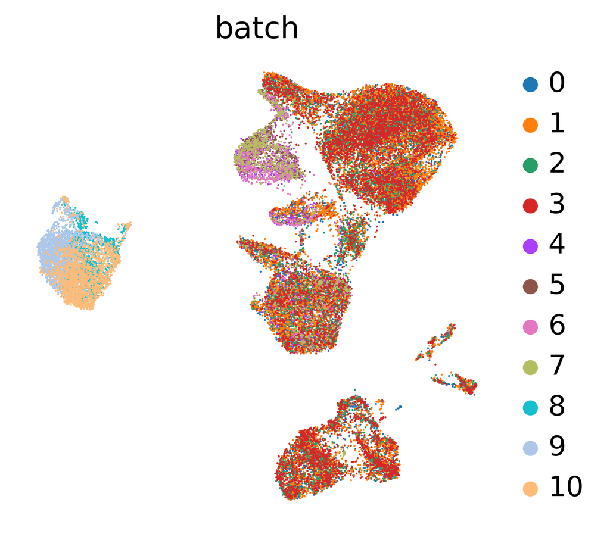

```
WARNING: saving figure to file figures/umapcellSource_preIntegration_6wk_TSC_from_start.svg
```

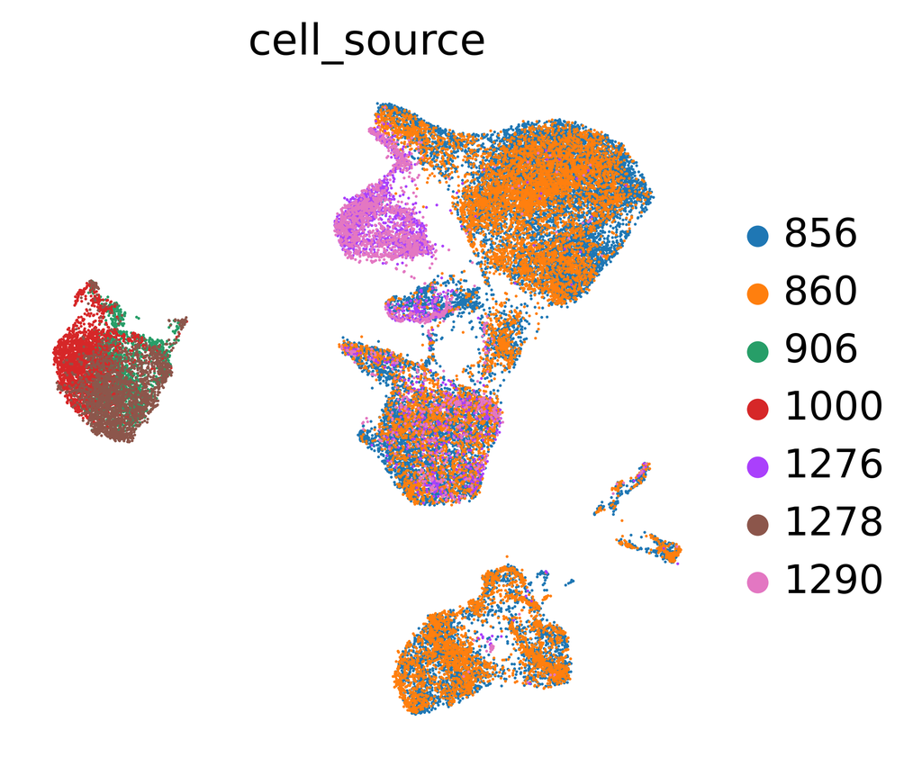

```python
#Generate before and after integration figures
sc.pl.umap(
    adata_6wk_TSC,
    color=["batch"],
    frameon=False)
sc.pl.umap(
    adata_6wk_TSC,
    color=["cell_source"],
    ncols=1,
    frameon=False)
```

```python
# use scVI latent space for post integration UMAP generation
sc.pp.neighbors(adata_6wk_TSC, use_rep="X_scVI")
sc.tl.umap(adata_6wk_TSC, min_dist=0.3)
```

```
computing neighbors
    finished: added to `.uns['neighbors']`
    `.obsp['distances']`, distances for each pair of neighbors
    `.obsp['connectivities']`, weighted adjacency matrix (0:00:01)
computing UMAP
    finished: added
    'X_umap', UMAP coordinates (adata.obsm) (0:00:09)
```

```
WARNING: saving figure to file figures/umapbatch_postIntegration_6wk_TSC_from_start.svg
```

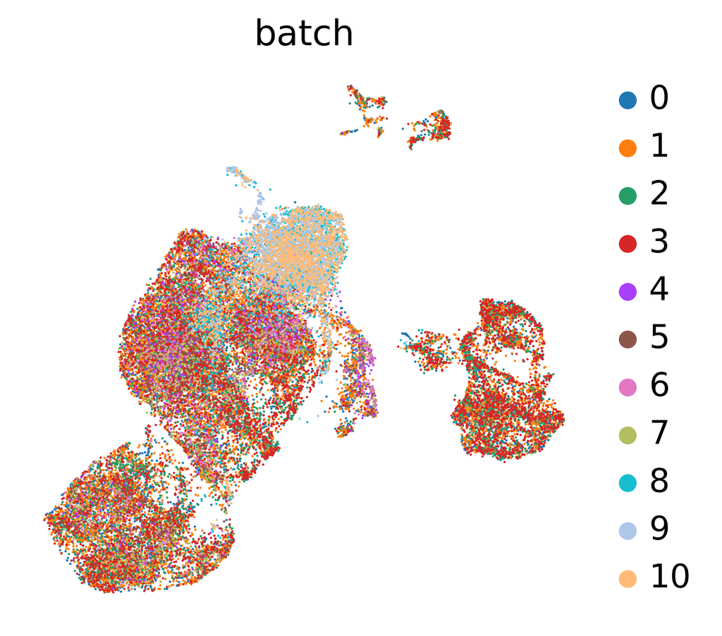

```
WARNING: saving figure to file figures/umapcellSource_postIntegration_6wk_TSC_from_start.svg
```

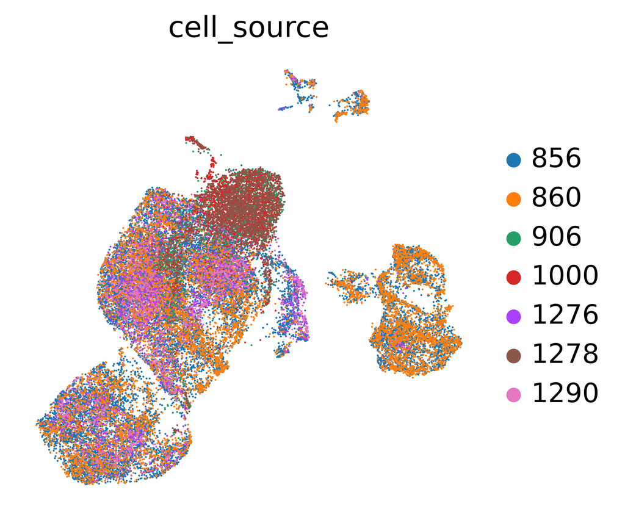

```python
sc.pl.umap(
    adata_6wk_TSC,
    color=["batch"],
    frameon=False)
sc.pl.umap(
    adata_6wk_TSC,
    color=["cell_source"],
    ncols=1,
    frameon=False)
```

Save the filtered data. To avoid error, first delete "predicted doublet" observation

```python
#del adata_6wk_TSC.obs['predicted_doublet']
```

```python
#Save data here:
adata_6wk_TSC.write_h5ad('adata_6wk_TSC_PostIntegration.h5ad')
```

```python
#To reload data and start from this point:
adata_6wk_TSC = sc.read('adata_6wk_TSC_PostIntegration.h5ad')
```

# Clustering and Annotation

```
running Leiden clustering
    finished: found 17 clusters and added
    'leiden_r0_75', the cluster labels (adata.obs, categorical) (0:00:12)
WARNING: saving figure to file figures/umap6wk_TSC_from_start_clustered_sub2.svg
```

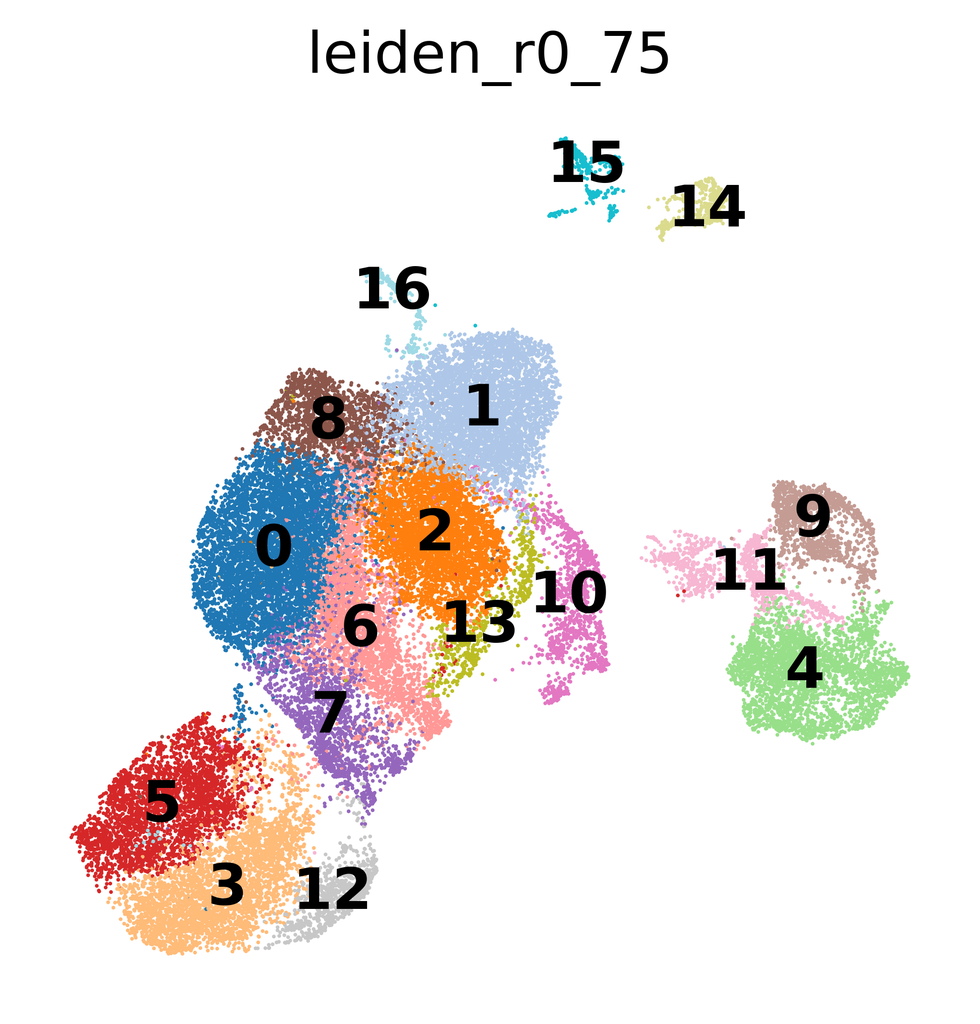

```python
sc.tl.leiden(adata_6wk_TSC, resolution=0.75, key_added='leiden_r0_75')
sc.pl.umap(adata_6wk_TSC, color=['leiden_r0_75'], palette='tab20', frameon=False,legend_loc='on data', save='6wk_TSC_clustered_FigS9b.svg')
```

Marker gene expression

```
WARNING: dendrogram data not found (using key=dendrogram_leiden_r0_75). Running `sc.tl.dendrogram` with default parameters. For fine tuning it is recommended to run `sc.tl.dendrogram` independently.
    using 'X_pca' with n_pcs = 50
Storing dendrogram info using `.uns['dendrogram_leiden_r0_75']`
WARNING: saving figure to file figures/dotplot_6wk_TSC_from_start_data_dotplot.svg
```

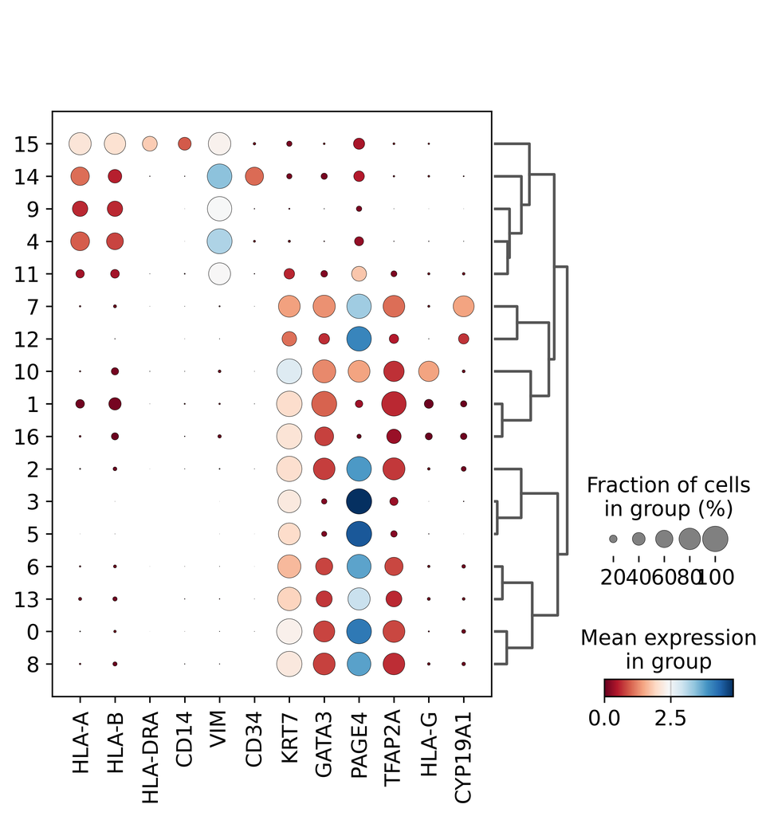

```python
sc.pl.dotplot(adata_6wk_TSC, var_names=['HLA-A','HLA-B','HLA-DRA','CD14','VIM','CD34','KRT7','GATA3','PAGE4','TFAP2A','HLA-G','CYP19A1'],
              groupby="leiden_r0_75",dendrogram=True,cmap='RdBu',save='6wk_TSC_dotplot_FigS9c.svg')
```

```python
adata_6wk_TSC_Troph = adata_6wk_TSC[adata_6wk_TSC.obs['leiden_r0_75'].isin(['0','1','2','3','5','6','7','8','10','12','13','16'])]
```

```python
#Save data here:
adata_6wk_TSC_Troph.write_h5ad('adata_6wk_TSC_Troph_PostTrophSelection.h5ad')
```

Annotate clusters

```
    using 'X_pca' with n_pcs = 50
Storing dendrogram info using `.uns['dendrogram_leiden_r0_75']`
WARNING: saving figure to file figures/dotplot_6wk_TSC_Troph_only_marker_expression_sub2.svg
```

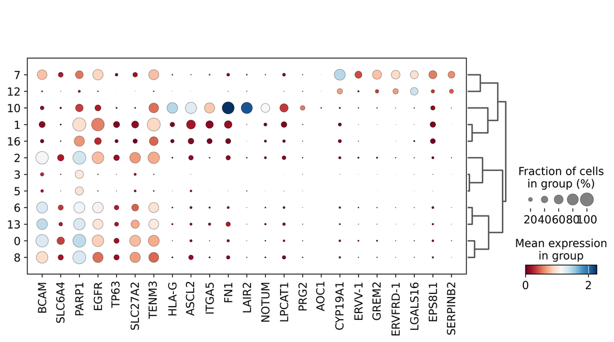

```python
sc.tl.dendrogram(adata_6wk_TSC_Troph, groupby='leiden_r0_75')
sc.pl.dotplot(adata_6wk_TSC_Troph, var_names=['BCAM','SLC6A4','PARP1','EGFR','TP63','SLC27A2','TENM3','HLA-G','ASCL2','ITGA5','FN1','LAIR2','NOTUM','LPCAT1','PRG2',
                                              'AOC1','CYP19A1','ERVV-1','GREM2','ERVFRD-1','LGALS16','EPS8L1','SERPINB2'],
              groupby="leiden_r0_75",dendrogram=True,cmap='RdBu',save='6wk_TSC_Troph_only_marker_expression_FigS9d.svg')
```

I want to create a new obs called "TSC" so I can show in the umap what is TSC and what is placental

```python
# Create a new category 'TSC' based on the values in 'Loc'
adata_6wk_TSC_Troph.obs['TSC'] = adata_6wk_TSC_Troph.obs['Loc'] == 'culture'

# Convert boolean values to True/False
adata_6wk_TSC_Troph.obs['TSC'] = adata_6wk_TSC_Troph.obs['TSC'].astype(bool)
```

Using the markers, clusters were annotated using broad trophoblast categories

```
WARNING: saving figure to file figures/umap6wk_TSC_umap_named_TSC_visual_sub2.svg
```

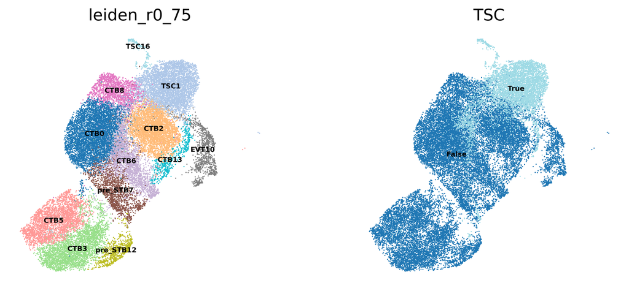

```python
cluster_names = ['CTB0', 'TSC1', 'CTB2', 'CTB3','CTB5','CTB6','pre_STB7','CTB8','EVT10','pre_STB12','CTB13','TSC16']
adata_6wk_TSC_Troph.rename_categories('leiden_r0_75', cluster_names)
sc.pl.umap(adata_6wk_TSC_Troph, color=['leiden_r0_75','TSC'], frameon=False, palette='tab20',legend_fontsize=6,legend_loc='on data',save='6wk_TSC_umap_named_TSC_FigS9e.svg')
```

```python
#Recalculate marker genes
sc.tl.rank_genes_groups(adata_6wk_TSC_Troph, groupby='leiden_r0_75', key_added='rank_genes_r0_75')
wk6_TSC_mark = pd.DataFrame(adata_6wk_TSC_Troph.uns['rank_genes_r0_75']['names'])
wk6_TSC_mark.head(30)
```

```
ranking genes
    finished: added to `.uns['rank_genes_r0_75']`
    'names', sorted np.recarray to be indexed by group ids
    'scores', sorted np.recarray to be indexed by group ids
    'logfoldchanges', sorted np.recarray to be indexed by group ids
    'pvals', sorted np.recarray to be indexed by group ids
    'pvals_adj', sorted np.recarray to be indexed by group ids (0:00:05)
```

|  | CTB0 | TSC1 | CTB2 | CTB3 | CTB5 | CTB6 | pre_STB7 | CTB8 | EVT10 | pre_STB12 | CTB13 | TSC16 |
| --- | --- | --- | --- | --- | --- | --- | --- | --- | --- | --- | --- | --- |
| 0 | EFEMP1 | FABP5 | HMGB2 | PAGE4 | RPL21 | MT-CO1 | CGA | ARL6IP1 | TPM1 | CGA | MT-CO1 | FTL |
| 1 | IFI6 | PPP1R14B | MT-CO1 | RPS27 | RPL41 | MT-CO2 | MALAT1 | PTTG1 | KRT19 | S100P | MT-CO2 | LGALS1 |
| 2 | SERPINF1 | TMSB4X | MT-ND4 | RPL21 | RPL13A | MALAT1 | TBX3 | HMGB1 | FSTL3 | PHLDA2 | MALAT1 | FABP5 |
| 3 | MT-CO1 | C1QBP | HIST1H4C | RPL13A | PAGE4 | MT-CO3 | INSL4 | STMN1 | SLC16A3 | KRT23 | MT-ND2 | S100A10 |
| 4 | SPINT1 | H2AFZ | STMN1 | RPL34 | RPL23A | MT-ND4 | SLC40A1 | TUBA1B | GLRX | INSL4 | MT-CO3 | TMSB4X |
| 5 | SPINT2 | LGALS1 | DEK | RPS14 | RPL11 | MT-ND2 | KRT23 | H2AFZ | GAPDH | PGF | MT-ND4 | PPP1R14B |
| 6 | APLP2 | TPM3 | MT-CO2 | RPS27A | RPL31 | MT-ND3 | CEBPB | RAN | ASCL2 | RPS27 | MT-CYB | H2AFZ |
| 7 | BCAM | EPCAM | H2AFZ | RPS25 | RPL17 | MT-CYB | SLC43A2 | HMGB2 | QSOX1 | GADD45G | MT-ND3 | C12orf75 |
| 8 | BSG | JPT1 | SMC4 | RPS12 | RPS3A | MT-ATP6 | LCMT1-AS2 | HMGN2 | CALD1 | ANXA1 | MT-ATP6 | JPT1 |
| 9 | MT-ND4 | CCT6A | MT-ND1 | RPL26 | RPL18A | MT-ND1 | GADD45G | MT-CO1 | COL4A1 | CEBPB | MT-ND1 | NME2 |
| 10 | MEST | SSR3 | MT-CO3 | RPL41 | RPL26 | MT-ND5 | S100P | LSM4 | MFAP5 | SLC40A1 | MT-ND5 | ACTB |
| 11 | FBLN1 | S100A16 | MT-ND2 | RPL31 | RPS27A | H19 | TOP1 | H2AFV | PGF | CYP11A1 | FUS | KRT8 |
| 12 | ITM2B | FTL | CDK1 | RPL23A | RPS27 | FBN2 | CDKN1C | BIRC5 | TFPI | EIF1 | APLP2 | ACTG1 |
| 13 | SMAGP | TUBA1C | MT-CYB | RPL27A | RPS15A | PEG10 | ANXA1 | LDHA | DIO2 | RPL34 | FBN2 | TPM1 |
| 14 | MT-CO3 | C12orf75 | TUBB | RPS18 | RPL35 | PEG3 | CSF3R | NUCKS1 | EFNA1 | NUPR1 | SYNE2 | S100A6 |
| 15 | MT-CO2 | CCND1 | PCLAF | RPL17 | RPS6 | N4BP2L2 | CLIP1 | MT-ND4 | LAIR2 | DAB2 | SON | COTL1 |
| 16 | MT-ND2 | TUBB2B | CKS1B | RPS15A | RPS15 | CSF3R | PRKCZ | HSP90AA1 | FN1 | FDX1 | MT-ND6 | KRT18 |
| 17 | JUN | PFKP | HELLS | RPLP1 | RPS25 | WSB1 | SQSTM1 | LY6E | IGFBP3 | HSPB1 | HNRNPA2B1 | PRDX1 |
| 18 | CTSC | CAP1 | DUT | RPS19 | RPS18 | KCNQ1OT1 | MUC15 | CDKN3 | SRI | LGALS16 | HSP90B1 | PSMB5 |
| 19 | SLC22A11 | ODC1 | TUBA1B | RPS13 | PTMA | SRSF5 | SLC22A11 | HNRNPA2B1 | CGA | HSPB8 | HNRNPU | SSR3 |
| 20 | COMT | KPNB1 | MALAT1 | RPL32 | TUBA1B | BCAM | SLC2A1 | MT-CO3 | B2M | PRKCZ | N4BP2L2 | S100A16 |
| 21 | FAM3B | SFN | PRC1 | RPL35A | RPS19 | DDB1 | ST3GAL4 | PTMS | TLE5 | HSD17B1 | PEG3 | TUBB2B |
| 22 | TINAGL1 | UBE2S | PCNA | RPL10A | HMGB2 | APLP2 | PGF | B2M | COTL1 | CDKN1C | MT-ND4L | CALM1 |
| 23 | PEG10 | SELENOW | MT-ATP6 | RPL11 | RPS12 | PNISR | NUCB2 | MT-CO2 | CD63 | ARG2 | PSAP | NOP10 |
| 24 | DUSP9 | YBX3 | TK1 | RPL10 | RPL35A | EGFR | ERVW-1 | HSPD1 | COL4A2 | SQSTM1 | WSB1 | SELENOW |
| 25 | CTSL | CYCS | TYMS | RPL18A | RPL34 | TCAF1 | NEAT1 | CCNB2 | FOS | COX6C | APP | BRI3 |
| 26 | BEX3 | CCT2 | NUSAP1 | RPS23 | HMGB1 | RBM39 | COBLL1 | CACYBP | TGFB1 | RPL23A | PDIA3 | SEC61B |
| 27 | SLC27A2 | HNRNPAB | FUS | RPS3A | RPS3 | DSP | TAX1BP1 | NDUFA4 | HLA-G | RPL21 | HELLS | DYNLL1 |
| 28 | MT-CYB | NME2 | TOP2A | RPS6 | RPLP1 | SIGLEC6 | SLC13A4 | YBX1 | LAPTM4A | TOP1 | SMC4 | FKBP1A |
| 29 | MALAT1 | CCT5 | GMNN | RPS15 | RPL32 | CCNL1 | ARID5B | MT-ND2 | HLA-C | S100A9 | ASPM | RALBP1 |

```python
#write this marker list to a file
wk6_TSC_mark.head(200).to_csv('wk6_TSC_named_marker_genes_leiden_r0_75_Supplementary_Data12.csv')
```

```
WARNING: saving figure to file figures/dendrogramadata_6wk_TSC_Troph_dendrogram_named.svg
```

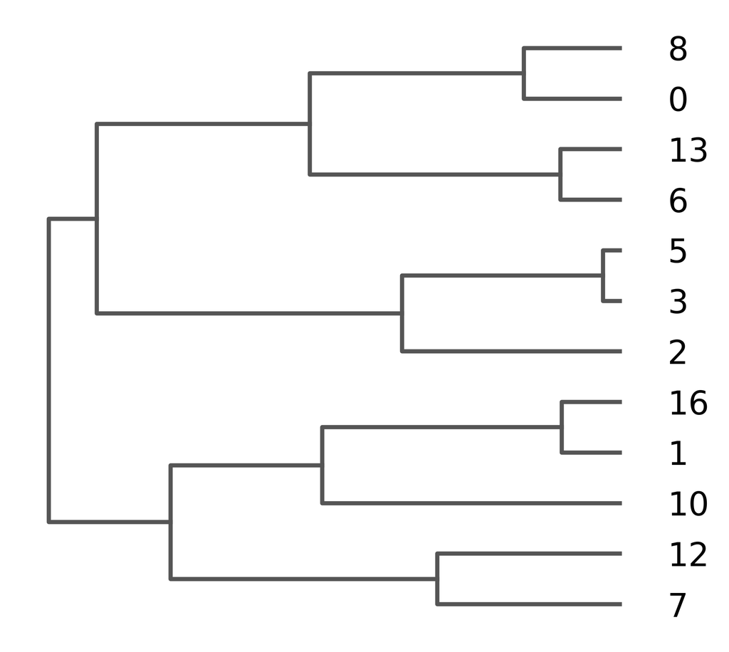

```python
sc.pl.dendrogram(adata_6wk_TSC_Troph,groupby='leiden_r0_75',orientation='left',save='adata_6wk_TSC_Troph_dendrogram_named_FigS9e.svg')
```

```python
#Save data here:
adata_6wk_TSC_Troph.write_h5ad('adata_6wk_TSC_Troph_only_named.h5ad')
```